# Evaluating the Impact of Orthogonal Correction on Simulated Group Discrimination 2

Tecla Duran Fort 2025-06-10

# 1. Introduction

This document reproduces the simulation strategy described in the report [**“Evaluating the Impact of Orthogonal Correction on Simulated Group Discrimination”**](https://github.com/tecladuran/gcims-workflows/blob/main/docs/Group_Simulation/simulation_plsda.md), but introduces an **automated tuning of the number of latent variables (`ncomp`)** in the PLS-DA model.

Instead of fixing `ncomp` to a predefined value, this version uses **cross-validation** to optimize the number of components in each iteration. The optimal number is chosen based on two criteria:

- It must mark the point where **accuracy improvements between consecutive components fall below 5%**, indicating a plateau.
- It must reach **at least 80% of the best classification accuracy** observed during cross-validation, avoiding understimating the number of components.

This tuning procedure enhances the robustness of the results and ensures fairer comparisons across perturbation levels and correction strategies.

The rest of the pipeline —including simulation of group differences, classification with PLS-DA, and evaluation via AUC — remains identical to the original version.

# 2. Load Data and Metadata

```r
set.seed(1234)
df <- read.csv("../../data/peak_table_var.csv")

meta <- df[, c("elapsed_time", "batch")]

# Get cluster names
clusters <- grep("^Cluster", names(df), value = TRUE)
```

## 2.1. Assign Classes

```r
# Assign random group labels
df$Group <- sample(rep(c("Control", "Cancer"), length.out = nrow(df)))
```

## Visualizing Group vs Technical Effects

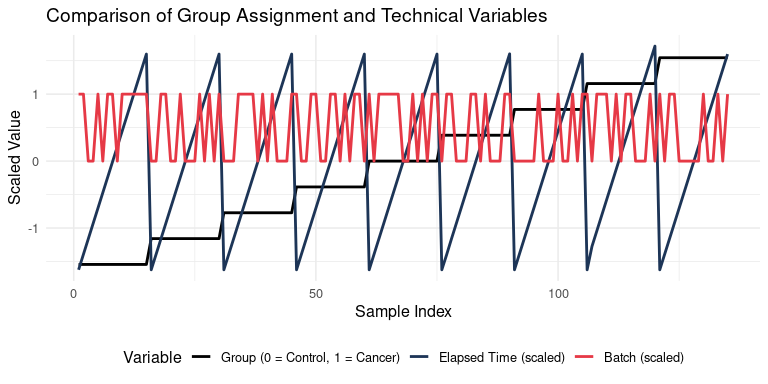

# 3. Function Definitions

## 3.1 Simulate Controlled Shift in One Cluster

```r
simulate_shift <- function(df, cluster, perc) {
  df_mod <- df
  mean_val <- mean(df[[cluster]], na.rm = TRUE)
  noise <- rnorm(nrow(df_mod), mean = perc * mean_val, sd = 0.05 * mean_val)
  df_mod[[cluster]][df_mod$Group == "Cancer"] <- df_mod[[cluster]][df_mod$Group == "Cancer"] + noise[df_mod$Group == "Cancer"]
  return(as.data.frame(df_mod))
}
```